# The simplest models of logistic and Poisson regressions using tabulated subset data

# Logistic regession model

## Model description

This simplest model describes only presence or absence of whitefish larvae $y$, not its density. Here the observational model is described as Bernoulli distribution given as:

$$y_i |m_i \sim Bernoulli(g^{-1}(m_i(x_i))),$$

where we assume logit transformation of the mean function $m(x)$

$$g(m_i(x_i))= logit(m_i(x_i)) = log\left(\frac{m_i(x_i)}{1-m_i(x_i)}\right)$$

The mean function $m(x)$ follows the logistic regression model:

$$m(x) = logit^{-1}(\alpha_0 + \alpha_1\delta_1(x_1)+ ... + \alpha_6x_6(x_1) + x_2\beta_1 + ... + x_6\beta_5).$$

In this model:

$\delta_d(x_1)=1$ if $x_1=d$ and zero otherwise, $\alpha_d \sim N(0,10)$ and $\beta_d \sim N(0,10), 0, ..., 5$

The priors are defined as:

$$\alpha_d \sim N(0,10)$$
and
$$\beta_d \sim N(0,10), d=0, ..., 5$$

The posterior distribution:

$$p(\alpha_0, \alpha_1, ..., \alpha_6, \beta_1, ... ,\beta_5 | y,x) = p(\alpha_0)p(\alpha_l) ... p(\alpha_6)p(\beta_1)...p(\beta_5)\prod_{i=1}^{n}p(y_i | \alpha_0,\alpha_1, ..., \alpha_5,\beta_1, ... ,\beta_5, x_i)$$

## Visualizing the study area and two environmental variables

We start with loading the smaller subset data (in tabular format) and visualizing the study area. First we plot the variable Distance to 20m deep water at the sampling locations. The locations of samling sites are marked in black.

```r
setwd("D:/Neli/MThesis/Ex_7_trials")

if (.Platform$OS.type != "windows") {
  if (Sys.getenv("RSTUDIO") == "1") {
    windows <- function( ... ) X11( ... )
  } else {
    windows <- dev.new
  }
}

library("rstan")
library(matrixStats)
options(mc.cores = parallel::detectCores())

library("raster")
```

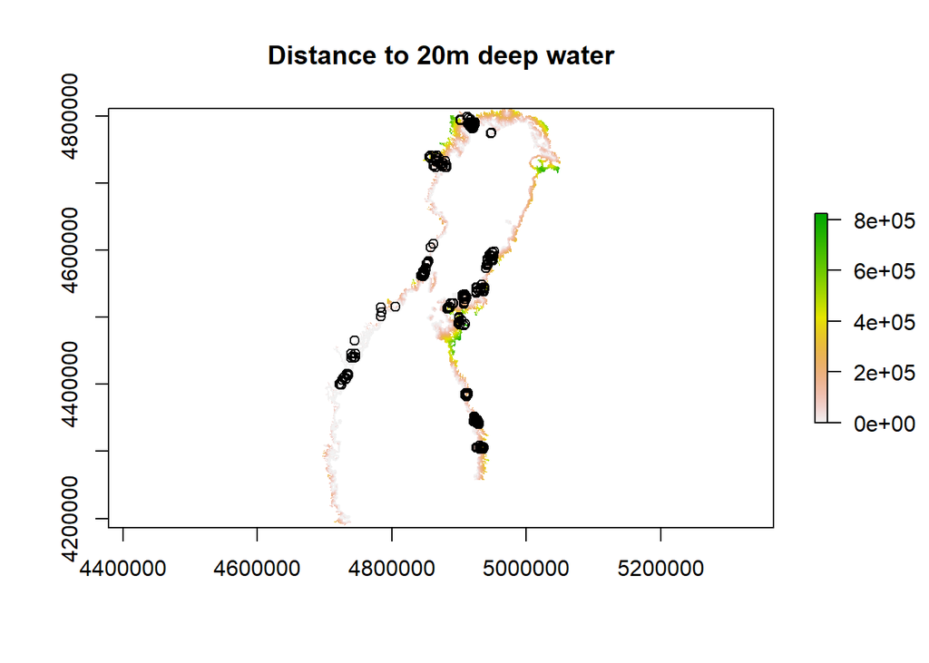

```r
library(Rcpp)
# Load the data
whitefish.dat = read.table("data_whitefish.txt", header=TRUE, sep="\t")
whitefish.raster = read.table("predraster_whitefish.txt", header=TRUE, sep="\t")

## The coordinate system in the data is ETRS89.
## This is a 3D cartesian coordinate system constructed specifically to European areas.
##  In whitefish.dat the coordinates are N_etrs89 E_etrs89
##  In whitefish.raster the coordinates are X Y

# First examine the data by plotting few of the raster layers

# Visualize few environmental covariates
e <- extent(cbind(whitefish.raster$X,whitefish.raster$Y))
r <- raster(e, ncol=length(unique(whitefish.raster$X)), nrow=length(unique(whitefish.raster$Y)))

z <- rasterize(cbind(whitefish.raster$X,whitefish.raster$Y), r, whitefish.raster$DIST20M, fun=mean)
plot(z, xlim=cbind(min(whitefish.raster$X),max(whitefish.raster$X)),
     ylim=cbind(min(whitefish.raster$Y),max(whitefish.raster$Y)), main="Distance to 20m deep water")

# Plot the locations of sampling sites
points(whitefish.dat$E_etrs89,whitefish.dat$N_etrs89)
```

The last ice cover day in 2009 at sampling locations is visualized on the next plot:

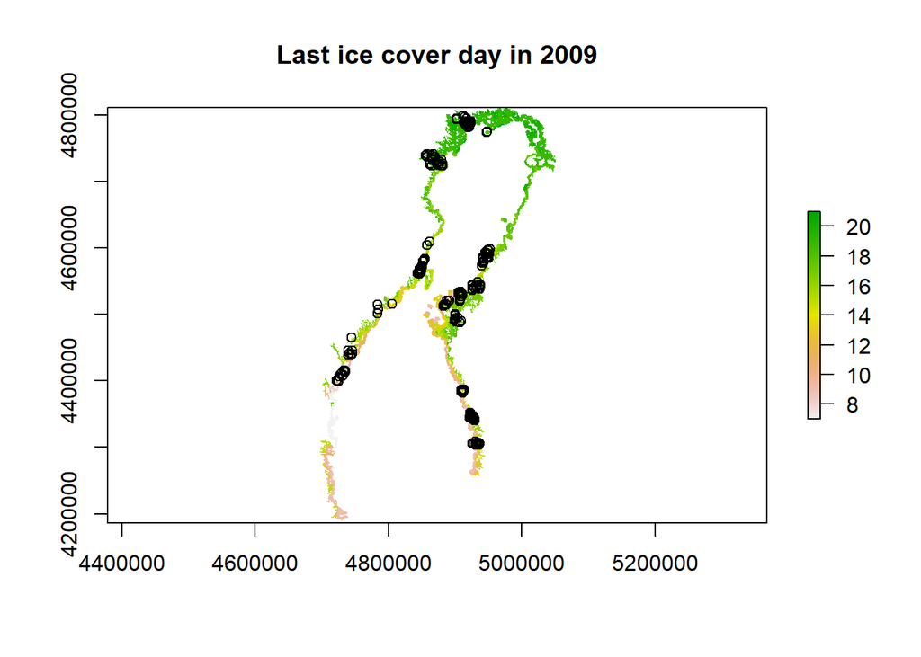

```r
# Plot Last ice cover day in 2009
z <- rasterize(cbind(whitefish.raster$X,whitefish.raster$Y), r, whitefish.raster$ICELAST09, fun=mean)
plot(z, xlim=cbind(min(whitefish.raster$X),max(whitefish.raster$X)),
     ylim=cbind(min(whitefish.raster$Y),max(whitefish.raster$Y)), main="Last ice cover day in 2009")
# Plot the locations of sampling sites
points(whitefish.dat$E_etrs89,whitefish.dat$N_etrs89)
```

## Performing logistic regression using Stan.

The environmental covariates are:

BOTTOMCLS - Bottom type classifiction, a categorical variable with the following classes: 0 = not shallow 1 = open water 2 = other 3 = sand 4 = sand/mud 5 = sand/stone

DIS_SAND - distance to sandy shore, continuous variable

FE300ME - The average fetch (opennes/exposure) over all directions, continuous variable

ICELAST09 - The last ice cover date in winter 2009-10, continuous variable

RIVERS - Influence of rivers (~weighted average distance to river mouths), continuous variable

SAL910WIN - Winter salinity in 2009-2010, continuous variable

The output variable is WHISUM - the number of whitefishes caught in sampling occasion.

In this simplest case we model only presence or absence of whitefish, because of which we transform it to 0/1 binary variable.

First we set up an standardize the data and prediction varables.

```r
# Set up data
s = as.matrix(cbind(whitefish.dat$E_etrs89,whitefish.dat$N_etrs89)) / 1000   # spatial coordinates in km
x = matrix(0,nrow=nrow(s),ncol=12)      # intercept + 6 BOTTOMCLS classes + 5 continues covariates
x[,1] = 1                             # Set the column corresponding to intercept to 1
x[whitefish.dat$BOTTOMCLS==0,2] = 1   # Set the elements corresponding to BOTTOMCLS = 0 to 1
x[whitefish.dat$BOTTOMCLS==1,3] = 1   # Set the elements corresponding to BOTTOMCLS = 1 to 1
x[whitefish.dat$BOTTOMCLS==2,4] = 1   # Set the elements corresponding to BOTTOMCLS = 2 to 1
x[whitefish.dat$BOTTOMCLS==3,5] = 1   # Set the elements corresponding to BOTTOMCLS = 3 to 1
x[whitefish.dat$BOTTOMCLS==4,6] = 1   # Set the elements corresponding to BOTTOMCLS = 4 to 1
x[whitefish.dat$BOTTOMCLS==5,7] = 1   # Set the elements corresponding to BOTTOMCLS = 5 to 1
xcont = as.matrix(cbind(whitefish.dat$DIS_SAND,
                        whitefish.dat$FE300ME,
                        whitefish.dat$ICELAST09,
                        whitefish.dat$RIVERS,
                        whitefish.dat$SAL910WIN))
stdxcont = apply(xcont, 2, sd)
mxcont = apply(xcont, 2, mean)
x[,8:12] = t( apply( t(apply(xcont,1,'-',mxcont)),1,'/',stdxcont) )    # "standardize" the continuous covariates

# End variable
#transform WHISUM to binary: 0 if 0, 1 otherwise
y1<-whitefish.dat$WHISUM
whitefish.dat$WHISUM[whitefish.dat$WHISUM > 0] <- 1
y = whitefish.dat$WHISUM               # number of counted fish larvae
#head(y)
#tail(y)

# Prediction variables
spred = as.matrix(cbind(whitefish.raster$X,whitefish.raster$Y)) / 1000  # spatial coordinates in km
xpred = matrix(0,nrow=nrow(spred),ncol=12)      # intercept + 6 BOTTOMCLS classes + 5 continues covariates
xpred[,1] = 1                             # Set the column corresponding to intercept to 1
xpred[whitefish.raster$BOTTOMCLS==0,2] = 1   # Set the elements corresponding to BOTTOMCLS = 0 to 1
xpred[whitefish.raster$BOTTOMCLS==1,3] = 1   # Set the elements corresponding to BOTTOMCLS = 1 to 1
xpred[whitefish.raster$BOTTOMCLS==2,4] = 1   # Set the elements corresponding to BOTTOMCLS = 2 to 1
xpred[whitefish.raster$BOTTOMCLS==3,5] = 1   # Set the elements corresponding to BOTTOMCLS = 3 to 1
xpred[whitefish.raster$BOTTOMCLS==4,6] = 1   # Set the elements corresponding to BOTTOMCLS = 4 to 1
xpred[whitefish.raster$BOTTOMCLS==5,7] = 1   # Set the elements corresponding to BOTTOMCLS = 5 to 1
xpredcont = as.matrix(cbind(whitefish.raster$DIS_SAND,
                            whitefish.raster$FE300ME,
                            whitefish.raster$ICELAST09,
                            whitefish.raster$RIVERS,
                            whitefish.raster$SAL910WIN))
xpred[,8:12] = t( apply( t(apply(xpredcont,1,'-',mxcont)),1,'/',stdxcont) )    # "standardize" the continuous covariates

#dim(x)
#length(y)
```

The Stan hierarchical model of logistic regression is given in the chunk bellow. We have used y ~ bernoulli_logit((x.beta)) instead y ~ bernoulli(inv_logit(x.beta)) since the function **bernoulli_logit** is numerically stable.

```stan
data {
  int<lower=1> N; //number of observations
  int<lower=1> Dx; //number of predictors + first column = intercept alpha_0
  matrix[N,Dx] x; //covariate matrix
  int<lower=0> y[N];
}

parameters {
  vector [Dx] beta;
}

model {
  //priors for alpha and beta coefficients
  //all alpha and beta coefficients are involved in beta column vector
  //beta =[alpha0, alpha1, ..., alpha6,beta1,...,beta5]
  //Set week priors for intercept and all other covariates
  for (i in 1:Dx)
    beta[i] ~ normal(0, 10);

  //the likelihood
  //y ~ bernoulli(inv_logit(x*beta)); - does not work; not stable numercally
  y ~ bernoulli_logit((x*beta));
}
```

Next we simulate and analyze the Stan model using MCMC simulations and statistics. We start 4 initial chains and check their mixing and convergence properties.

```r
 #x = x[seq(1,217,length=60),]
 #y = y[seq(1,217,length=60)]

whitefish_dat <- list(Dx = ncol(x),
                      N = nrow(x),
                      x = x,
                      y = y)

#set initial values of the chains
#rnorm(#samples, mu,sigma)
set.seed(124)
#init1 <-list(beta=as.vector(rep(0,ncol(x))))
init1 <- list(beta=as.vector(rnorm(ncol(x),0,10)))
init2 <- list(beta=as.vector(rnorm(ncol(x),0,10)))
init3 <- list(beta=as.vector(rnorm(ncol(x),0,10)))
init4 <- list(beta=as.vector(rnorm(ncol(x),0,10)))
inits = list(init1,init2,init3,init4)

# Compile the STAN model
library(rstudioapi)
fit <- stan(file = "Log_reg_whitefish.stan", data = whitefish_dat, warmup=200,
            iter = 1000, init=inits , control = list(adapt_delta = 0.99), pars=c("beta"))
beta <- as.matrix(fit)

print(fit)
```

```
## Inference for Stan model: Log_reg_whitefish.
## 4 chains, each with iter=1000; warmup=200; thin=1;
## post-warmup draws per chain=800, total post-warmup draws=3200.
##
##             mean se_mean   sd    2.5%     25%     50%     75%   97.5% n_eff
## beta[1]     0.93    0.14 3.79   -6.60   -1.56    0.90    3.38    8.79   696
## beta[2]     0.48    0.15 3.98   -7.35   -2.10    0.47    3.10    8.54   735
## beta[3]     0.48    0.14 3.81   -7.16   -2.01    0.54    2.99    8.17   700
## beta[4]    -1.05    0.14 3.93   -8.77   -3.60   -1.05    1.56    6.82   749
## beta[5]    -0.60    0.15 3.86   -8.46   -3.14   -0.52    1.93    7.00   697
## beta[6]    -0.58    0.14 3.79   -8.43   -3.06   -0.54    1.95    6.91   691
## beta[7]     0.12    0.14 3.79   -7.69   -2.31    0.18    2.66    7.55   704
## beta[8]    -1.27    0.01 0.35   -1.97   -1.50   -1.25   -1.03   -0.61  1882
## beta[9]    -0.09    0.00 0.18   -0.44   -0.21   -0.08    0.04    0.26  1766
## beta[10]    0.05    0.01 0.23   -0.40   -0.10    0.06    0.21    0.50  1714
## beta[11]   -0.04    0.00 0.18   -0.39   -0.16   -0.04    0.08    0.31  2073
## beta[12]    0.04    0.01 0.39   -0.72   -0.23    0.05    0.31    0.81  1685
## lp__     -117.63    0.09 2.63 -123.64 -119.17 -117.29 -115.70 -113.51   944
##          Rhat
## beta[1]  1.01
## beta[2]  1.01
## beta[3]  1.01
## beta[4]  1.00
## beta[5]  1.00
## beta[6]  1.01
## beta[7]  1.01
## beta[8]  1.00
## beta[9]  1.00
## beta[10] 1.00
## beta[11] 1.00
## beta[12] 1.00
## lp__     1.01
##
## Samples were drawn using NUTS(diag_e) at Tue Jun 02 23:51:59 2020.
## For each parameter, n_eff is a crude measure of effective sample size,
## and Rhat is the potential scale reduction factor on split chains (at
## convergence, Rhat=1).
```

```r
#lp_ ->log density up to a constant
# https://www.jax.org/news-and-insights/jax-blog/2015/october/lp-in-stan-output
#log density = log likelihood of the observations conditioned on the posterior parameters: p(y | p_post).
```

```r
#summary(fit)
```

We continue to analyse MCMC convergence by visual analysis of mixing and stationarity via taceplots of all $\beta$ parameters.

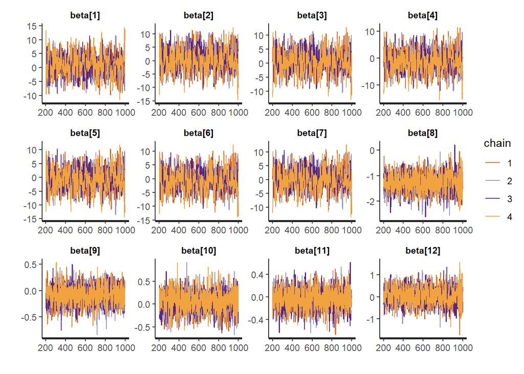

```r
#parameter's matrix:
b <- as.matrix(fit)
beta<-b[,-13]
colnames(beta)<-c("alpha_0","alpha_1","alpha_2","alpha_3","alpha_4","alpha_5","alpha_6","beta_1","beta_2","beta_3","beta_4","beta_5")

stan_trace(fit, pars = c("beta"))
```

These plots show good mixing of all chains and therefore we can conclude that the convergence is achieved.

Posterior densities and histograms of all estimated $\beta$ are:

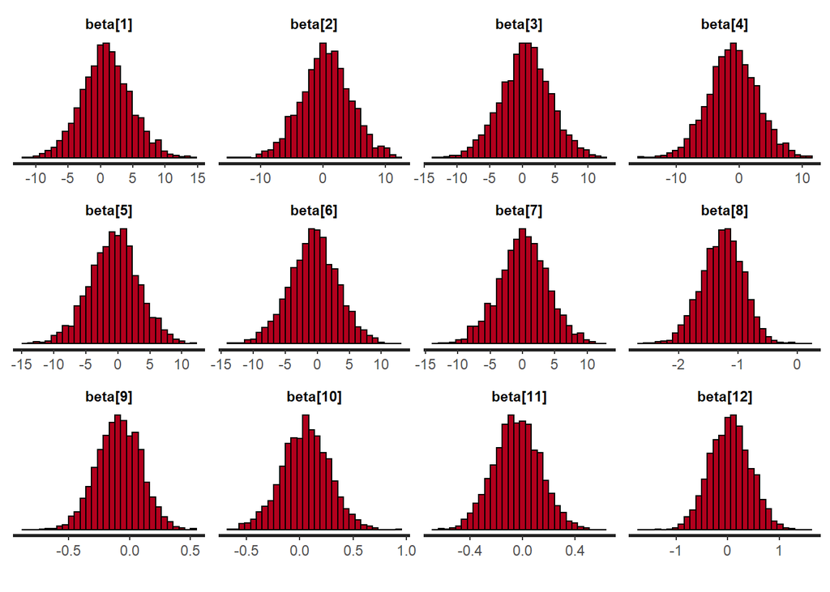

```r
#posterior densties and histograms
stan_hist(fit, pars='beta', bins=30)
```

The credible intervals of all $\beta$ estimates are:

```
## ci_level: 0.5 (50% intervals)
```

```
## outer_level: 0.95 (95% intervals)
```

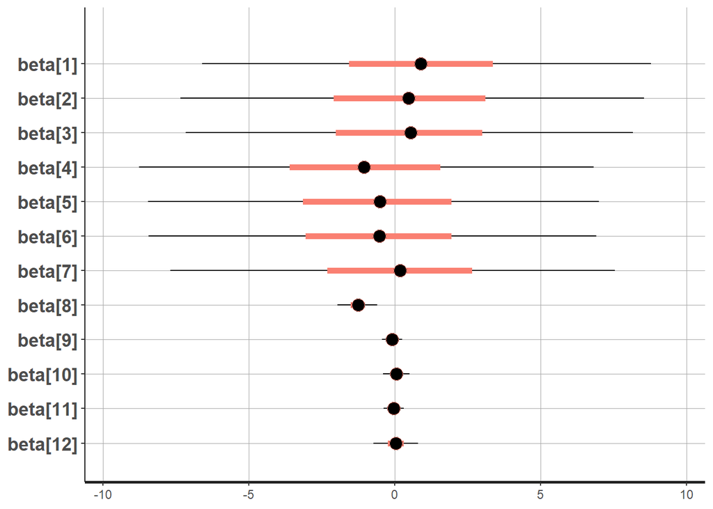

```r
#show credible intervals
plot(fit, show_density = FALSE, ci_level = 0.5, outer_level = 0.95, fill_color = "salmon", pars='beta')
```

```r
#pairwise correlations
#pairs(fit)
```

```r
#par(mar = c(1, 1, 1, 1)) # Set the margin on all sides to 6
#acf(beta)
```

Thinned paramters and theirs mean values:

```r
beta_thinned = as.matrix(beta[seq(1,800,4),])
#dim(beta_thinned)
#head(beta_thinned)
#mean estimates
means_b = colMeans(beta_thinned)
means_b
```

```
##     alpha_0     alpha_1     alpha_2     alpha_3     alpha_4     alpha_5
##  0.80721212  0.53759023  0.57329593 -0.85109410 -0.46819099 -0.42294687
##     alpha_6      beta_1      beta_2      beta_3      beta_4      beta_5
##  0.23390458 -1.24350255 -0.06374995  0.04612588 -0.05948868  0.02874725
```

## Test model accuracy

Here we make model predictions from Stan model in R. [Here](https://medium.com/@alex.pavlakis/making-predictions-from-stan-models-in-r-3e349dfac1ed) 3 ways to make predictions are described: 1. Predict outside Stan: use estimated posteriors in Stan to build the model and generate the output outside Stan, in R. 2. Predict with Stan: define only data (x_test + estimated parameters) and generated quantities (define output y_test). Model and parameter parts are empty.  
3. Fit-and-predict: except data (x_train, x_test, y_train), model (y_train) and paraeter parts I n Stan we define also y_test in generated quantities.

Here we apply the first approach. We use log regression model in R to simulate y<sub>predicted</sub>. Use MCMC parameter estimates for beta (from x,y data) and x<sub>predicted</sub> to obtain y<sub>predicted</sub>.

We first take random sample from all estimated $\beta$, all train x data, and simulate the logistic regression model in R to obtain y<sub>pred</sub>:

```r
lin_comb <- x%*%t(beta)
#prob of success
#prob==prob1
prob <- 1/(1 + exp(-lin_comb))
#prob1 <- exp(lin_comb)/(1 + exp(lin_comb))
#dim(x)[1] - number of observations we want to see
# # of trials per observation = 1 = Bernoulli
#prob - prob of success of each trial, dim(prob) = 217x3200
set.seed(56)
#dim(prob)=217x3200
y_pred <- rbinom(dim(x)[1], 1, prob)
# Accuracy
mean(y_pred == y)
```

```
## [1] 0.6267281
```

We repeat the same procedure for estimating the accuracy using train data, but now usng thinned $\beta$ estimates:

```r
#1.2 test model accuracy via r using thinned beta estimates
lin_comb_bt <- x%*%t(beta_thinned)
prob_bt <- 1/(1 + exp(-lin_comb_bt))
set.seed(123)
y_pred_bt<- rbinom(dim(x)[1], 1, prob_bt)
# Accuracy
mean(y_pred_bt == y)
```

```
## [1] 0.6820276
```

```r
#CONCLUSION: THE ACCURACY WHEN USE THINNED ESTIMATES IS BETTER
```

Conclusion: The acuracy when use thinned parameter estimates $\beta_{thinned}$ is better.

```r
beta_means<-rowMeans(t(beta))
lin_comb <- xpred%*%beta_means
prob <- 1/(1 + exp(-lin_comb))
#prepare to plot mean_prob, sdth, q_lower and q_upper
mth<-0
sdth<-0
q_lower<-0
q_upper<-0
for (i in 1:dim(xpred)[1]) {
  lin_comb_i<-xpred[i,]%*%t(beta)
  th<-1/(1+exp(-lin_comb_i))
  mth[i]<-mean(th)
  q_lower[i]<-quantile(th,0.025)
  q_upper[i]<-quantile(th,0.975)
  sdth[i]<-sd(th)
}
```

Next visualize these values about whitefish presence:

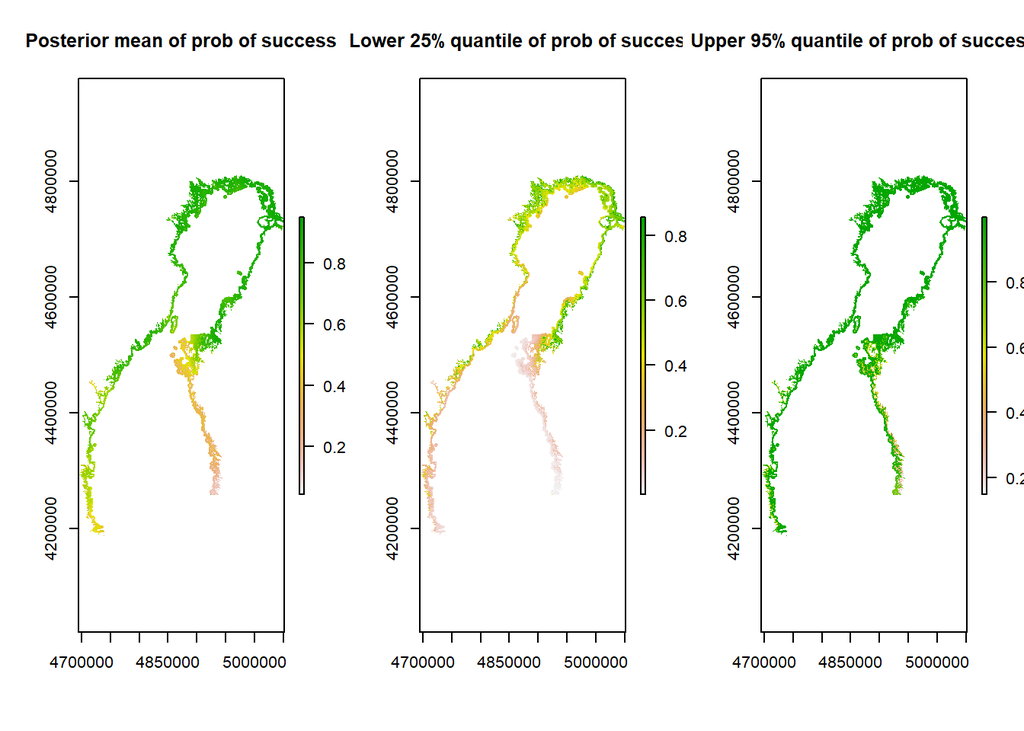

```r
#Visualize mth, q_lower, q_upper<-0
#windows()
par(mfrow=c(1,3))
# Posterior mean of prob
z <- rasterize(cbind(whitefish.raster$X,whitefish.raster$Y), r, mth, fun=mean)
plot(z, xlim=cbind(min(whitefish.raster$X),max(whitefish.raster$X)),
     ylim=cbind(min(whitefish.raster$Y),max(whitefish.raster$Y)), main="Posterior mean of prob of success")
#points(whitefish.dat$E_etrs89,whitefish.dat$N_etrs89)

# Posterior lower quantile prob
z <- rasterize(cbind(whitefish.raster$X,whitefish.raster$Y), r, q_lower, fun=mean)
plot(z, xlim=cbind(min(whitefish.raster$X),max(whitefish.raster$X)),
     ylim=cbind(min(whitefish.raster$Y),max(whitefish.raster$Y)), main="Lower 25% quantile of prob of success")
#points(whitefish.dat$E_etrs89,whitefish.dat$N_etrs89)

# Posterior upper quantile of prob
z <- rasterize(cbind(whitefish.raster$X,whitefish.raster$Y), r, q_upper, fun=mean)
plot(z, xlim=cbind(min(whitefish.raster$X),max(whitefish.raster$X)),
     ylim=cbind(min(whitefish.raster$Y),max(whitefish.raster$Y)), main="Upper 95% quantile of prob of success")
```

```r
#points(whitefish.dat$E_etrs89,whitefish.dat$N_etrs89)
```

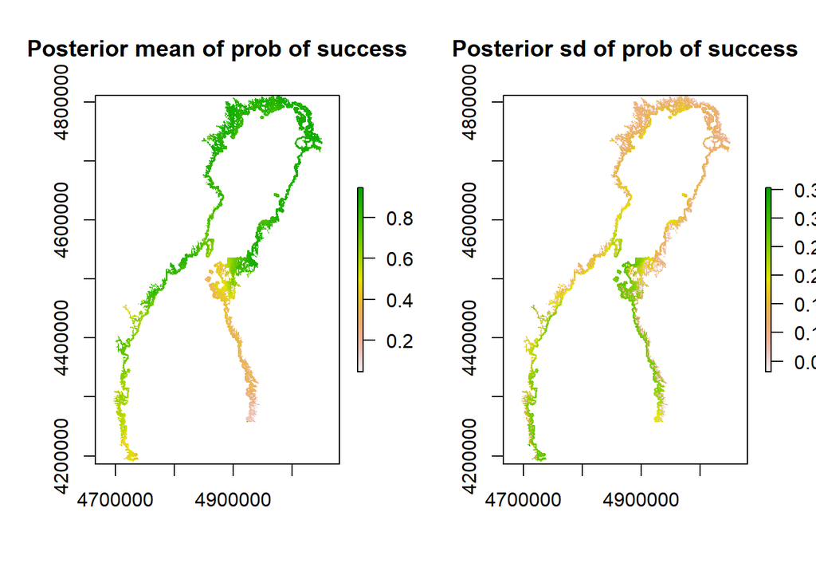

```r
#Posterior mean and sd of probability of success
#windows()
par(mfrow=c(1,2))
# Posterior mean of prob
z <- rasterize(cbind(whitefish.raster$X,whitefish.raster$Y), r, mth, fun=mean)
plot(z, xlim=cbind(min(whitefish.raster$X),max(whitefish.raster$X)),
     ylim=cbind(min(whitefish.raster$Y),max(whitefish.raster$Y)), main="Posterior mean of prob of success")
#points(whitefish.dat$E_etrs89,whitefish.dat$N_etrs89)

# Posterior sd of prob
z <- rasterize(cbind(whitefish.raster$X,whitefish.raster$Y), r, sdth, fun=mean)
plot(z, xlim=cbind(min(whitefish.raster$X),max(whitefish.raster$X)),
     ylim=cbind(min(whitefish.raster$Y),max(whitefish.raster$Y)), main="Posterior sd of prob of success")
```

```r
#points(whitefish.dat$E_etrs89,whitefish.dat$N_etrs89)
```

## Evaluating the model: CV, WAIC and DIC measures of predictive accuracy

In all these 3 measures the goodness-of-fit is calculated as the average likelihood of the data given the parameters (i.e., $p(y|\theta)$ over the entire posterior, and flexibility is calculated by some measure of variability of the likelihood over the posterior.

As a base for this work I have used the model solution of Exercise 2, Week 5, of Advanced Bayesian Inference course, and also Chapter 7 of course book.

### K-fold cross-validation log predictive density and effective number of parameters

The Stan model used for this task is:

```stan
data {
  int<lower=1> N; //number of observations - train data
  int<lower=1> Dx; //number of predictors + first column = intercept alpha_0
  matrix[N,Dx] x; //covariate matrix
  int<lower=0> y[N]; //observed y values

  int<lower=1> Np; //number of observations - test data
  matrix[Np,Dx] xp; //covariate matrix - predicted
  int<lower=0> yp[Np];//predicted  y values
}

parameters {
  vector [Dx] beta;
}

model {
  //priors for alpha and beta coefficients
  //all alpha and beta coefficients are involved in beta column vector
  //beta =[alpha0, alpha1, ..., alpha6,beta1,...,beta5]
  //Set week priors for intercept and all other covariates
  for (i in 1:Dx)
    beta[i] ~ normal(0, 10);

  //the likelihood
  //y ~ bernoulli(inv_logit(x*beta)); - does not work; not stable numercally
  //y ~ bernoulli_logit((x*beta));
  y ~ bernoulli_logit(multiply(x,beta));
}

//define log_lik to be usd in LOO CV
generated quantities {
  vector[Np] Lik;
  for (n in 1:Np) {
    //The log Bernoulli probability mass of y given chance of success  inv_logit(x[n] * beta)
    // here we compute likelihood, and take log in r-code. Because we need to take column means?
    Lik[n] = exp(bernoulli_logit_lpmf(yp[n] | xp[n] * beta));
  }
}
```

The $k$-fold-CV estimate is:
$$\mathrm{CV} = \frac{1}{n} \sum_{i=1}^n \log p(y_i|x_i,D_{\setminus k(i)}) \approx \frac{1}{n} \sum_{i=1}^S \frac{1}{S} \log p(y_i|x_i,\theta^{s})$$

where $\theta^s\sim p(\theta|D_{\setminus k(i)})$ and $D_{\setminus k(i)}$ denotes the data from where the block including the data point $i$ is excluded. $S$ is the number of posterior simulations, and $n$ is the number of observations

```r
data_cv <- cbind(x,y)
# shuffle the data so that cross validation is done with random divisions
rows = sample(nrow(data_cv))
df = data_cv[rows,]
x<-df[,-13]
y <- df[,13]


K = 10;              # 10-folds for CV
n_groups <- ceiling(nrow(df)/K) #number of K-groups for predicting
logLikest = c(); # lppd_tilde - log point-wise posterior predictive density estimates


for (i in 1:n_groups) {
  if (K*i < nrow(df)) {
    ind1 = (10*(i-1)+1):(K*i)    # indexes of test data for first n_groups-1 groups
    #ind2 = which(y != y[ind1]);  # indexes of training data - this is not correct code
    #since compare y values, which could be equal or not (0/1)
  }
  else {
    ind1 = (10*(i-1)+1):nrow(df)    # indexes of test data for last group
    #ind2 = which(y != y[ind1]);  # indexes of training data - not correct code
  }
  # dataset for the ith fold
  dataset = list(Dx = ncol(x), N = length(y[-ind1]), y = y[-ind1], x = x[-ind1, ],
                 Np = length(ind1), yp = y[ind1], xp = x[ind1, ])

  #inits
  set.seed(124)
  #init1 <-list(beta=as.vector(rep(0,ncol(x))))
  init1 <- list(beta=as.vector(rnorm(ncol(x),0,10)))
  init2 <- list(beta=as.vector(rnorm(ncol(x),0,10)))
  ## initializing with init2 does not produce samples in Stan
  ## ?? How to choose initial values of the chains?
  init3 <- list(beta=as.vector(rnorm(ncol(x),0,10)))
  init4 <- list(beta=as.vector(rnorm(ncol(x),0,10)))
  inits = list(init1, init2, init3, init4)

  # posterior samples
  post = stan("Log_reg_whitefish_CV.stan", data = dataset, warmup = 300,
              iter = 1100, init=inits, control = list(max_treedepth = 15), pars=c("Lik"))
  #print(post)
  #take out the last column, lp_
  M = as.data.frame(post)
  M=M[,-ncol(M)]
  # log point-wise posterior predictive density estimates
  #head(M$Lik)
  logLikest[ind1] = log(colMeans(M))
  #print(logLikest[ind1])
}

KfoldCV = mean(logLikest)
cat(paste("KfoldCV: ", KfoldCV))
```

```
## KfoldCV:  -0.58221599486607
```

```r
print("")
```

```
## [1] ""
```

```r
cat(paste("k-fold-CV*2n: ", -2*length(y)*KfoldCV))
```

```
## k-fold-CV*2n:  252.681741771875
```

Compute $lppd$ = computed log pointwise predictive density =
$$\text{computed lppd} = \sum_{i=1}^n{log} \sum_{i=1}^S \frac{1}{S} \log p(y_i|x_i,\theta^{s})$$

```r
#compute lppd = mean(colmeans(log_likelihood(all data = train data)))
fit1 <- stan(file = "Log_reg_whitefish.stan", data = whitefish_dat, warmup=300,
            iter = 1100, init=inits , control = list(max_treedepth = 15), pars=c("lik"))

MM = as.data.frame(fit1)
MM=MM[,-ncol(MM)]
logLikest = log(colMeans(MM))

lppd = mean(logLikest)
cat(paste("lppd: ", lppd))
```

```
## lppd:  -0.513412079613459
```

```r
print("")
```

```
## [1] ""
```

```r
cat(paste("lppd*2n: ", -2*length(y)*lppd))
```

```
## lppd*2n:  222.820842552241
```

As it is ilustrated in [the course book], the effective number of parameters depends on the data even in a fixed model with fixed true parameters. An estimate of effective numbers of parameters using the cross-validation measures is (the book, eq. 7.15):

$$p_{k-cv} = lppd - lppd_{k-cv}$$
$lppd$ is the log pointwise predictive density, and $lppd_{k-cv}$ is the cross-validated pointwise predictive accuracy.

```r
#eff_N_par<-lppd-KfoldCV
eff_N_par<--length(y)*lppd+length(y)*KfoldCV
cat(paste("effective number of parameters: ", eff_N_par))
```

```
## effective number of parameters:  -14.9304496098167
```

### Widely applicable information criteria WAIC

This criteria is computed according the following formulae:

$$\mathrm{WAIC}=-2 \sum_{i=1}^n \log p(y_i|D) + 2p_{\mathrm{WAIC}}$$

where
$$\sum_{i=1}^n \log p(y_i|D) \approx \sum_{i=1}^n \log \left( \frac{1}{S} \sum_{s=1}^S p(y_i|\theta^s) \right)$$
and $\theta^s\sim p(\theta|D)$, and
$$p_{\mathrm{WAIC}}= \sum_{i=1}^n \mathrm{Var}_{post}[\log p(y_u|\theta)]$$

```r
dataset1 = list(Dx = ncol(x), N = length(y), y = y, x = x,
                Np = length(y), yp = y, xp = x)
post1 = stan("Log_reg_whitefish_CV.stan", data = dataset1, warmup = 300,
             iter = 1100, init=inits, control = list(max_treedepth = 15), pars=c("Lik","beta"))

M1 = as.data.frame(post1)
#MM=MM[,-ncol(MM)]
MM=M1[,1:217] #lik columns
logLikest = log(colMeans(MM))

#ElogLik1 = log(apply(MM, 2, mean)) - same as logLikest = log_x

ElogLik =  apply(log(MM), 2, mean)  #E(log_x)

ElogLik2 = apply((log(MM))^2, 2, mean) #(E(log_x))^2

p_WAIC = sum(ElogLik2 - ElogLik^2)

WAIC = -2*sum(logLikest) + 2*p_WAIC
cat(paste("WAIC: ", WAIC))
```

```
## WAIC:  248.658252096616
```

```r
#effective number of parameters
eff_p = (lppd -p_WAIC)
#eff_p<- 2*(lppd - sum(logLikest))
cat(paste("eff_p: ", eff_p))
```

```
## eff_p:  -13.4026643768253
```

### Deviance information criteria DIC

It i defined as:
$$DIC = -2 \log p(y| \hat{\theta}_{\mathrm{Bayes}}) + 2p_{\mathrm{DIC}}$$
where
$$p_{\mathrm{DIC}} = 2 (\log p(y|\hat{\theta}_{\mathrm{Bayes}}) - \mathrm{E}_{\mathrm{post}}[\log p(y|\theta)])$$

```r
#first compute logLikfix
beta_post=M1[,218:229]
beta_means<-rowMeans(t(beta_post))
lin_comb <- x%*%beta_means
prob <- 1/(1 + exp(-lin_comb))
set.seed(56)

logLikfix = sum(dbinom(y, 1, prob, log=TRUE))

p_DIC = 2* (logLikfix - mean(rowSums(log(MM))) )

DIC = - 2*logLikfix + 2*p_DIC
cat(paste("DIC: ", DIC))
```

```
## DIC:  245.482373703684
```

All 3 information criteria together:

```r
cat(paste("k-fold-CV*2n: ", -2*length(y)*KfoldCV,"\nWAIC: ", WAIC,"\nDIC: ", DIC))
```

```
## k-fold-CV*2n:  252.681741771875
## WAIC:  248.658252096616
## DIC:  245.482373703684
```

### Question: How to interpret these values, if we assume that they are correct?

### Does the computed effective number of parameters make sense?

# The Poison log-linear mopdel using Stan log-parametrization

The model in Stan:

```stan
data {
  int<lower=1> N; //number of observations
  int<lower=1> Dx; //number of predictors + first column = intercept alpha_0
  matrix[N,Dx] x; //covariate matrix
  int<lower=0> y[N];
}

parameters {
  vector [Dx] beta;
}

model {
  //priors for alpha and beta coefficients
  //all alpha and beta coefficients are involved in beta column vector
  //beta =[alpha0, alpha1, ..., alpha6,beta1,...,beta5]
  //Set week priors for intercept and all other covariates
  for (i in 1:Dx)
    beta[i] ~ normal(0, 10);

  //the likelihood
  //y ~ poisson_log(log_theta), log_theta = x*beta
  y ~ poisson_log((x*beta));
}

//define log_lik to be usd in LOO CV
generated quantities {
  vector[N] log_lik;
  for (n in 1:N) {
    //probability mass function
    //Increment target log probability density with poisson_log_lpmf( n | log_theta)
    //dropping constant additive terms.
    log_lik[n] = poisson_log_lpmf(y[n] | x[n] * beta);
  }
}
```

We repeat the same step of model analysis as in logistic regression model. We again start start 4 initial chains and check their mixing and convergence properties. Look the summary of the results, check Rhat vallues and effective sizes, and plot some important dependences.

```r
whitefish_dat <- list(Dx = ncol(x),
                      N = nrow(x),
                      x = x,
                      y = y1)
set.seed(124)
#init1 <-list(beta=as.vector(rep(0,ncol(x))))
init1 <- list(beta=as.vector(rnorm(ncol(x),0,10)))
init2 <- list(beta=as.vector(rnorm(ncol(x),0,10)))
init3 <- list(beta=as.vector(rnorm(ncol(x),0,10)))
init4 <- list(beta=as.vector(rnorm(ncol(x),0,10)))
inits = list(init1,init2,init3,init4)

# Compile the STAN model
#if we want to have an access to the generated quantities, we have to omit pars - argument
fit <- stan(file = "Poisson_reg_whitefish.stan", data = whitefish_dat, warmup=300,
            iter = 1100, init=inits , control = list(max_treedepth = 15), pars=c("beta")) #control = list(adapt_delta = 0.99)
```

```r
#windows()
print(fit)
```

```
## Inference for Stan model: Poisson_reg_whitefish.
## 4 chains, each with iter=1100; warmup=300; thin=1;
## post-warmup draws per chain=800, total post-warmup draws=3200.
##
##              mean se_mean   sd     2.5%      25%      50%      75%    97.5%
## beta[1]      2.19    0.16 3.86    -5.32    -0.33     2.22     4.64     9.90
## beta[2]      1.04    0.16 3.86    -6.59    -1.44     1.02     3.57     8.54
## beta[3]      1.78    0.16 3.86    -5.93    -0.67     1.74     4.31     9.30
## beta[4]     -0.53    0.16 3.86    -8.26    -2.97    -0.50     2.02     7.03
## beta[5]     -1.15    0.16 3.87    -8.92    -3.63    -1.15     1.37     6.41
## beta[6]      1.36    0.16 3.86    -6.33    -1.08     1.35     3.88     8.88
## beta[7]      1.13    0.16 3.86    -6.57    -1.33     1.10     3.66     8.65
## beta[8]     -0.17    0.00 0.02    -0.21    -0.18    -0.17    -0.16    -0.13
## beta[9]     -0.15    0.00 0.01    -0.18    -0.16    -0.15    -0.14    -0.13
## beta[10]     0.07    0.00 0.02     0.04     0.06     0.07     0.08     0.11
## beta[11]    -0.30    0.00 0.01    -0.33    -0.31    -0.30    -0.29    -0.28
## beta[12]     0.14    0.00 0.02     0.09     0.12     0.14     0.16     0.19
## lp__     20711.73    0.07 2.39 20706.05 20710.35 20712.03 20713.43 20715.44
##          n_eff Rhat
## beta[1]    559    1
## beta[2]    558    1
## beta[3]    559    1
## beta[4]    560    1
## beta[5]    558    1
## beta[6]    558    1
## beta[7]    559    1
## beta[8]   1710    1
## beta[9]   2770    1
## beta[10]  1755    1
## beta[11]  2281    1
## beta[12]  1458    1
## lp__      1047    1
##
## Samples were drawn using NUTS(diag_e) at Wed Jun 03 00:06:59 2020.
## For each parameter, n_eff is a crude measure of effective sample size,
## and Rhat is the potential scale reduction factor on split chains (at
## convergence, Rhat=1).
```

```r
#summary(fit)            # summary
```

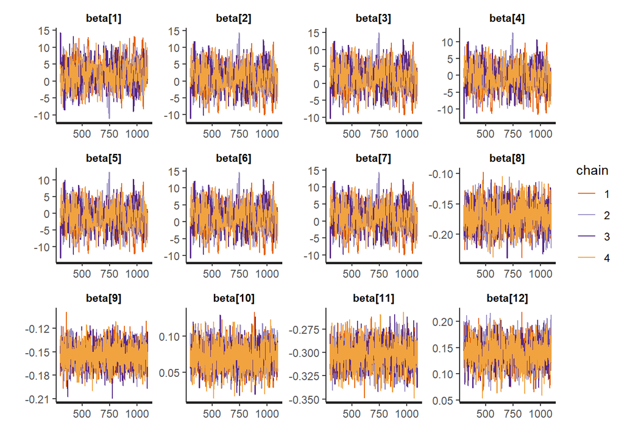

```r
stan_trace(fit, pars = c("beta"))         # traceplot
```

```r
#posterior densties and histograms
#stan_dens(fit, pars='beta')
```

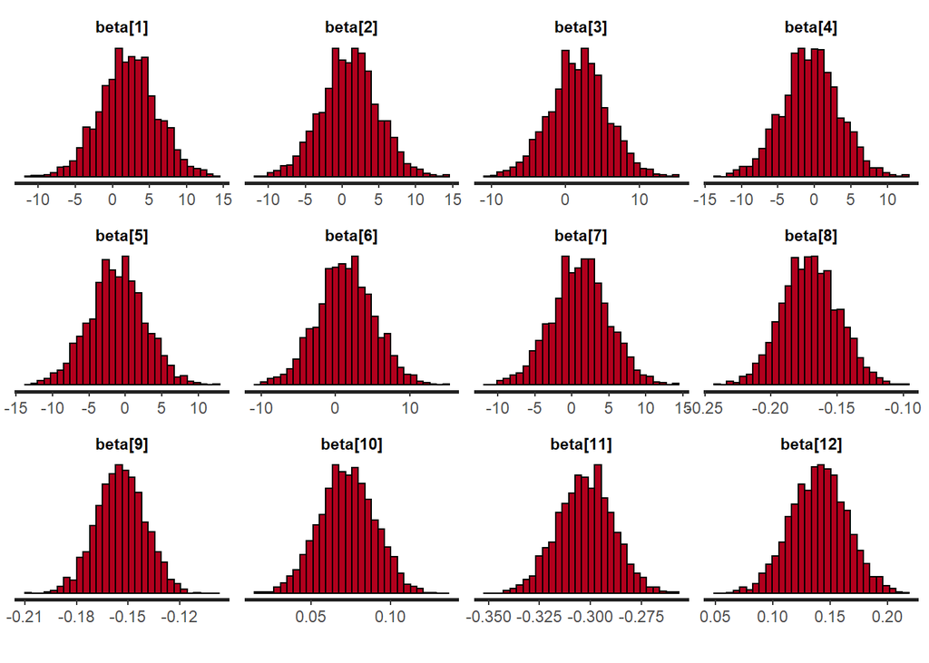

```r
stan_hist(fit, pars='beta', bins=30)
```

```
## ci_level: 0.5 (50% intervals)
```

```
## outer_level: 0.95 (95% intervals)
```

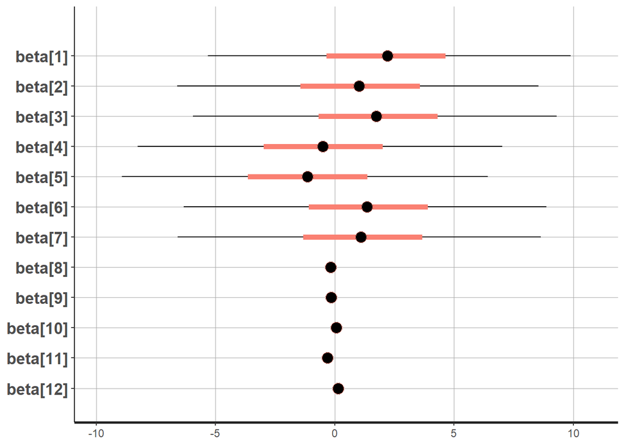

```r
#show credible intervals
plot(fit, show_density = FALSE, ci_level = 0.5, outer_level = 0.95, fill_color = "salmon", pars='beta')
```

```r
#pairwise correlations
#pairs(fit)

#parameter's matrix:
b <- as.matrix(fit)
beta<-b[,-13]
colnames(beta)<-c("alpha_0","alpha_1","alpha_2","alpha_3","alpha_4","alpha_5","alpha_6","beta_1","beta_2","beta_3","beta_4","beta_5")
```

```r
#plot autocorrelation function of all alpha and beta parameters:
#acf(b)
#acf(beta)
```

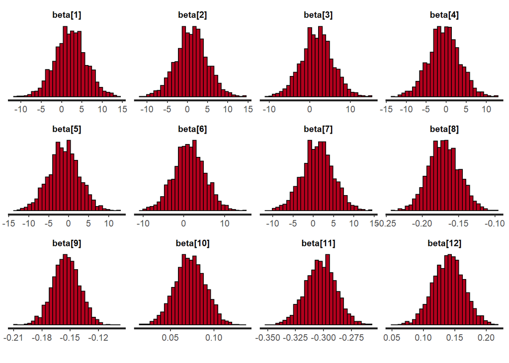

```r
# posterior density of parameters beta - histograms
quietgg(h <- stan_hist(fit, pars = "beta"))
```

```r
beta_thinned = as.matrix(beta[seq(1,800,4),])
#dim(beta_thinned)
#head(beta_thinned)
#mean estimates
means_b = colMeans(beta_thinned)
means_b
```

```
##     alpha_0     alpha_1     alpha_2     alpha_3     alpha_4     alpha_5
##  2.45889146  0.76804494  1.51244450 -0.81216013 -1.42675606  1.09726458
##     alpha_6      beta_1      beta_2      beta_3      beta_4      beta_5
##  0.85771932 -0.17177473 -0.15444836  0.07219556 -0.30250647  0.14088532
```

```r
#plot pairwise (auto)correlations
#acf(beta_thinned)
```

## Test model accuracy

We use posterior $\beta$ estimates and the data about covariates $x$ to simulate predicted $y$ values using samples generated in R. First we use all $\beta$ estimates:

```r
set.seed(78)
lin_comb <- x%*%t(beta)
#lambda = exp(lin_comb); Stan: alpha = log(lambda)=lin_comb
lambda <- exp(lin_comb)
#rpois(n,lambda), n-number of simulated points
y_pred <- rpois(dim(x)[1], lambda)
# Accuracy
mean(y_pred == y1)
```

```
## [1] 0.00921659
```

### Very low accuracy, why?

Next we use only $\beta_{thinned}$, 200 simulated values:

```r
#1.2 test model accuracy via r using thinned beta estimates
set.seed(78)
lin_comb_bt <- x%*%t(beta_thinned)
#lambda = exp(lin_comb); Stan: alpha = log(lambda)=lin_comb
lambda_t <- exp(lin_comb_bt)
#rpois(n,lambda), n-number of simulated points
y_pred_t <- rpois(dim(x)[1], lambda_t)
# Accuracy
mean(y_pred_t == y1)
```

```
## [1] 0.00921659
```

## What is wrong here, why the accuracy is so low?

Conclusion: The accuracy in both cases is the same and very low.

## Visualizing predictions for whitefish larval density $\lambda$ using the predicted covariates $x_{pred}$

We predict $\lambda$ using the Poisson log regression model in R and covariates data $x_{pred}$, and plot them on the raster:

```r
set.seed(123)
lin_comb_bt <- xpred%*%t(beta_thinned)
lambda_bt <- exp(lin_comb_bt)
y_pred_bt<- rpois(dim(xpred)[1], lambda_bt)
```

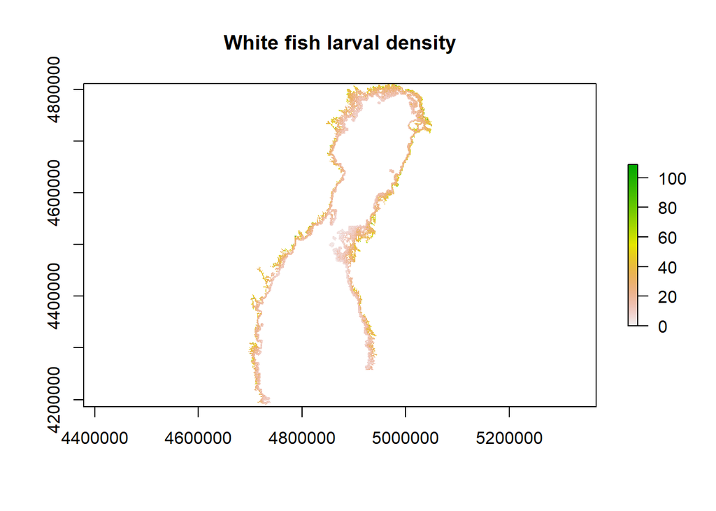

```r
z <- rasterize(cbind(whitefish.raster$X,whitefish.raster$Y), r, y_pred_bt, fun=mean)
plot(z, xlim=cbind(min(whitefish.raster$X),max(whitefish.raster$X)),
     ylim=cbind(min(whitefish.raster$Y),max(whitefish.raster$Y)), main="White fish larval density")
```

## Evaluating the model: CV, WAIC and DIC measures of predictive accuracy

### K-fold cross-validation log predictive density and effective number of parameters

The Stan model used for this task is:

```stan
data {
  int<lower=1> N; //number of observations - train data
  int<lower=1> Dx; //number of predictors + first column = intercept alpha_0
  matrix[N,Dx] x; //covariate matrix
  int<lower=0> y[N]; //observed y values

  int<lower=1> Np; //number of observations - test data
  matrix[Np,Dx] xp; //covariate matrix - predicted
  int<lower=0> yp[Np];//predicted  y values
}


parameters {
  vector [Dx] beta;
}

model {
  //priors for alpha and beta coefficients
  //all alpha and beta coefficients are involved in beta column vector
  //beta =[alpha0, alpha1, ..., alpha6,beta1,...,beta5]
  //Set week priors for intercept and all other covariates
  for (i in 1:Dx)
    beta[i] ~ normal(0, 10);

  //the likelihood
  //y ~ poisson_log(log_theta), log_theta = x*beta
  //y ~ poisson_log((x*beta));
  y ~ poisson_log(multiply(x,beta));
}

//define log_lik to be usd in LOO CV
generated quantities {
  vector[Np] Lik;
  for (n in 1:Np) {
    //probability mass function
    //Increment target log probability density with poisson_log_lpmf( n | log_theta)
    //dropping constant additive terms.
    Lik[n] = exp(poisson_log_lpmf(yp[n] | xp[n] * beta));
  }
}
```

K-fold cross validation, K=10:

```r
data_cv <- cbind(x,y1)
# shuffle the data so that cross validation is done with random divisions
rows = sample(nrow(data_cv))
df = data_cv[rows,]
x<-df[,-13]
y <- df[,13]


K = 10;              # 10-folds for CV
n_groups <- ceiling(nrow(df)/K) #number of K-groups for predicting
logLikest = c(); # lppd_tilde - log point-wise posterior predictive density estimates


inits = list(init1, init2,init3, init4)
for (i in 1:n_groups) {
  if (K*i < nrow(df)) {
    ind1 = (10*(i-1)+1):(K*i)    # indexes of test data for first n_groups-1 groups
    #ind2 = which(y != y[ind1]);  # indexes of training data - this is not correct code
    #since compare y values, which could be equal or not (0/1)
  }
  else {
    ind1 = (10*(i-1)+1):nrow(df)    # indexes of test data for last group
    #ind2 = which(y != y[ind1]);  # indexes of training data - not correct code
  }
  # dataset for the ith fold
  dataset = list(Dx = ncol(x), N = length(y[-ind1]), y = y[-ind1], x = x[-ind1, ],
                 Np = length(ind1), yp = y[ind1], xp = x[ind1, ])

  # posterior samples
  post = stan("Poisson_reg_whitefish_CV.stan", data = dataset, warmup = 300,
              iter = 1100, init = inits, control = list(max_treedepth = 15), pars=c("Lik"))
  #print(post)
  #take out the last column, lp_
  M = as.data.frame(post)
  M=M[,-ncol(M)]
  # log point-wise posterior predictive density estimates
  #head(M$Lik)
  logLikest[ind1] = log(colMeans(M))
  #print(logLikest[ind1])
}
KfoldCV = mean(logLikest)
cat(paste("KfoldCV: ", KfoldCV))
```

```
## KfoldCV:  -Inf
```

```r
cat(paste("k-fold-CV*2n: ", -2*length(y)*KfoldCV))
```

```
## k-fold-CV*2n:  Inf
```

The effective number of parameters:

```r
#compute lppd = mean(colmeans(log_likelihood(all data = train data)))
#use the original stan file without division train/test data
fit1 <- stan(file = "Poisson_reg_whitefish.stan", data = whitefish_dat, warmup=300,
             iter = 1100, init=inits , control = list(max_treedepth = 15), pars=c("lik"))
MM = as.data.frame(fit1)
MM=MM[,-ncol(MM)]
logLikest = log(colMeans(MM))

lppd = mean(logLikest)
cat(paste("lppd: ", lppd))
```

```
## lppd:  -Inf
```

```r
eff_N_par<--length(y)*lppd+length(y)*KfoldCV
cat(paste("effective number of parameters: ", eff_N_par))
```

```
## effective number of parameters:  NaN
```

### Widely applicable information criteria WAIC

```r
dataset1 = list(Dx = ncol(x), N = length(y), y = y, x = x,
                Np = length(y), yp = y, xp = x)
post1 = stan("Poisson_reg_whitefish_CV.stan", data = dataset1, warmup = 300,
             iter = 1100, init=inits, control = list(max_treedepth = 15), pars=c("Lik","beta"))
M1 = as.data.frame(post1)
#MM=MM[,-ncol(MM)]
MM=M1[,1:217] #lik columns
logLikest = log(colMeans(MM))
#ElogLik1 =  log(apply(MM, 2, mean))  #logLikest
#ElogLik1
#logLikest == ElogLik1
#ElogLik1 = log(apply(MM, 2, mean)) - same as logLikest = log_x

ElogLik =  apply(log(MM), 2, mean)  #E(log_x)

ElogLik2 = apply((log(MM))^2, 2, mean) #(E(log_x))^2

p_WAIC = sum(ElogLik2 - ElogLik^2)

WAIC = -2*sum(logLikest) + 2*p_WAIC
cat(paste("WAIC: ", WAIC))
```

```
## WAIC:  NaN
```

Effective number of parameters:

```r
#effective number of parameters
WAIC1 = lppd -p_WAIC
eff_p<- 2*(lppd - sum(logLikest))
cat(paste("WAIC1: ", eff_p, WAIC1))
```

```
## WAIC1:  NaN NaN
```

### Deviance information criteria DIC

```r
#first compute logLikfix
beta_post=M1[,218:229]
beta_means<-rowMeans(t(beta_post))
lin_comb_b <- x%*%beta_means
lambda_b <- exp(lin_comb_b)

set.seed(123)
logLikfix = sum(dpois(y, lambda_b, log=TRUE))

p_DIC = 2* (logLikfix - mean(rowSums(log(MM))) )

DIC = - 2*logLikfix + 2*p_DIC
cat(paste("DIC: ", DIC))
```

```
## DIC:  Inf
```

```r
#All 3 information criteria together:
cat(paste("k-fold-CV*2n: ", -2*length(y)*KfoldCV,"\nWAIC: ", WAIC,"\nDIC: ", DIC))
```

```
## k-fold-CV*2n:  Inf
## WAIC:  NaN
## DIC:  Inf
```

### Next:

- To include error term $\varepsilon$ in log regression model
- Spatial effects in Poisson model
- LOO CV for model comparison.